# Predviđanje dijabetesa kod žena pomoću logističke regresije

## Logistička regresija

Modelom logističke regresije opisujemo vezu između prediktora, koji mogu biti neprekidni, binarni, kategorički, i kategoričke zavisne promenljive. Zapravo ocenjujemo verovatnoće pripadanja svakoj kategoriji za dat skup prediktora. Razlikujemo binarnu, normalnu i ordinalnu logističku regresiju. Mi ćemo se ovde baviti binarnom regresijom. Binarna logistička regresija je logistička regresija kod koje je ciljna (zavisna) promenljiva binarna, npr. da li će se nešto desiti ili ne. U slučaju binarne smatramo da je ciljna promenljiva indikator, pa njene vrednosti kodiramo sa 0 i 1, za neuspeh i uspeh. Za ovaj problem klasifikacije možemo koristiti linearnu regresiju. Jedan način da se to uradi je da ako je fitovana vrednost linearnom regresijom veća od neke konstante, npr. 0.5, onda to klasifikujemo kao tačno, u suprotnom kao netačno.

## Šta je dijabetes?

**Dijabetes** je hronična bolest kod koje organizam proizvodi ili ne proizvodi ili neadekvatno koristi hormon pankreasa *insulin*. Dijabetes takođe može biti kombinacija oba mehanizma. Insulin kontroliše koncentraciju *glukoze* i količinu koja se apsorbuje u ćelijama.

Kako mozak koristi isključivo glukozu, neophodno je da se nivo šećera održava na zadovoljavajućem minimumu.

U slučaju da je nivo šećera nedovoljan, odnosno nizak, (hipoglikemija) osoba nije u stanju da rezonski postupa, a ukoliko je previsok (hiperglikemija), osoba ima dijabetes.

**Cilj projekta**

Cilj našeg projekta je da uz pomoć logističke regresije na osnovu baze, koja sadrži podatke o ženama iz indijanskog plemena Pima, predvidimo da li će osoba dobiti dijabetes u narednih 5 godina

Učitavanje biblioteka potrebnih za dalji rad:

```r
library(caret)
library(faraway)
```

## Podaci

Baza koju ćemo koristiti sastoji se iz sledećih obeležja:

- pregnant - koliko je puta osoba bila trudna
- glucose - koncentracija glukoze u krvi
- diastolic - dijastolni krvni pritisak
- triceps - debljina koznog nabora tricepsa (mm)
- insulin - količina insulina
- bmi - indeks telesne mase
- diabetes - funkcija koja ocenjuje verovatnocu dijabetesa na osnovu porodicne istorije
- age - godine
- test - da li pacijent pokazuje znate dijabetesa

## Analiza podataka

```
##     pregnant         glucose        diastolic         triceps
##  Min.   : 0.000   Min.   :  0.0   Min.   :  0.00   Min.   : 0.00
##  1st Qu.: 1.000   1st Qu.: 99.0   1st Qu.: 62.00   1st Qu.: 0.00
##  Median : 3.000   Median :117.0   Median : 72.00   Median :23.00
##  Mean   : 3.845   Mean   :120.9   Mean   : 69.11   Mean   :20.54
##  3rd Qu.: 6.000   3rd Qu.:140.2   3rd Qu.: 80.00   3rd Qu.:32.00
##  Max.   :17.000   Max.   :199.0   Max.   :122.00   Max.   :99.00
##     insulin           bmi           diabetes           age
##  Min.   :  0.0   Min.   : 0.00   Min.   :0.0780   Min.   :21.00
##  1st Qu.:  0.0   1st Qu.:27.30   1st Qu.:0.2437   1st Qu.:24.00
##  Median : 30.5   Median :32.00   Median :0.3725   Median :29.00
##  Mean   : 79.8   Mean   :31.99   Mean   :0.4719   Mean   :33.24
##  3rd Qu.:127.2   3rd Qu.:36.60   3rd Qu.:0.6262   3rd Qu.:41.00
##  Max.   :846.0   Max.   :67.10   Max.   :2.4200   Max.   :81.00
##       test
##  Min.   :0.000
##  1st Qu.:0.000
##  Median :0.000
##  Mean   :0.349
##  3rd Qu.:1.000
##  Max.   :1.000
```

Prikazacemo raspodele obelezja *insulin*, *glucose*, *triceps*, *diastolic* i *bmi* u odnosu na to da li osoba pokazuje simptome dijabetesa ili ne. Ova obelezja su odabrana iz razloga sto se mogu primetiti neke neprirodnosti unutar podataka.

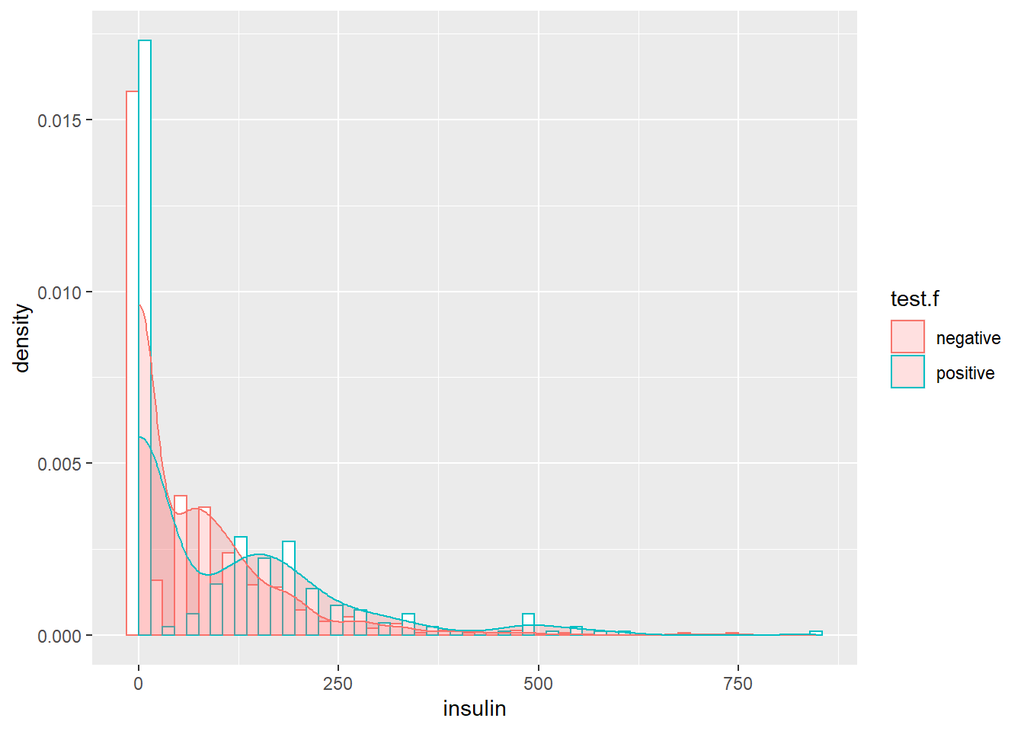

```r
library(ggplot2)

pima$test.f <- factor(pima$test)
levels(pima$test.f) <- c("negative","positive")

ggplot(pima, aes(x=insulin, y=..density.., color=test.f)) +
  geom_histogram(position='dodge',binwidth = 30, fill="white") +
  geom_density(alpha=.2, fill="#FF6666")
```

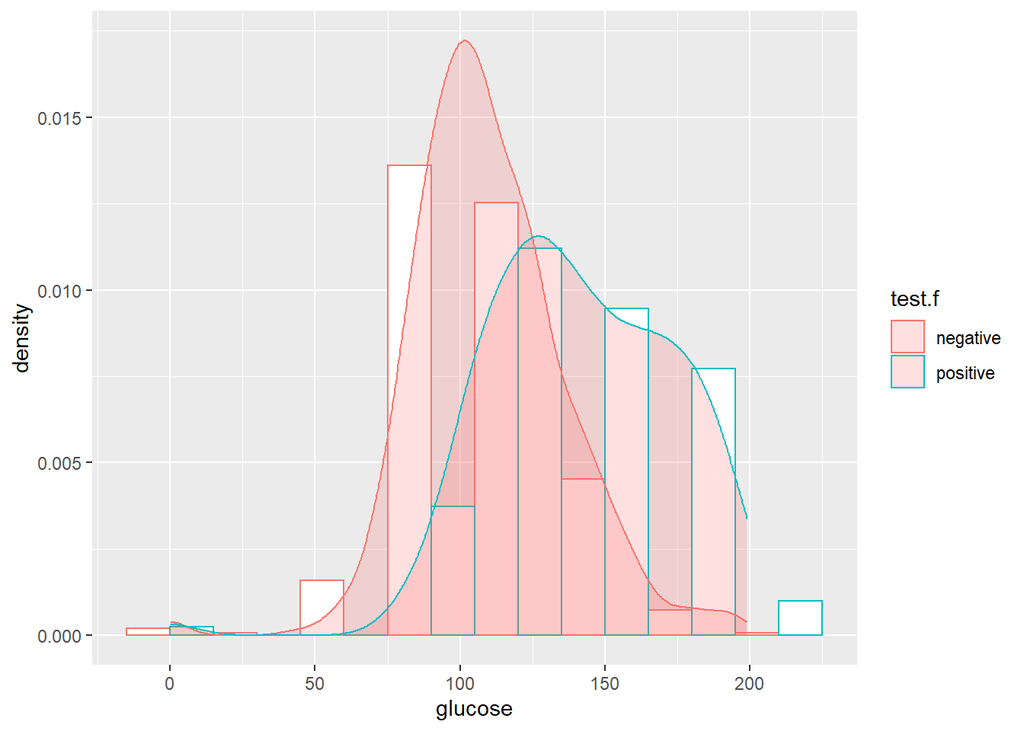

```r
ggplot(pima, aes(x=glucose, y=..density.., color=test.f)) +
  geom_histogram(position='dodge',binwidth = 30, fill="white") +
  geom_density(alpha=.2, fill="#FF6666")
```

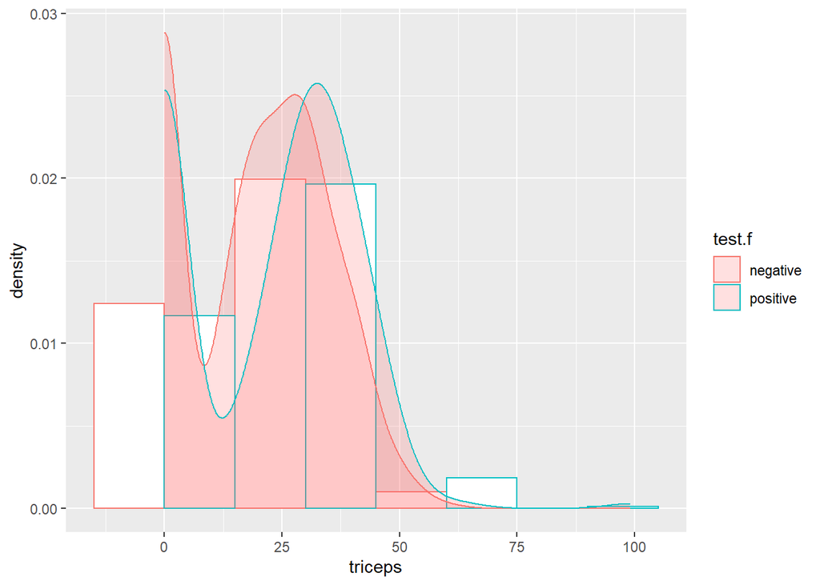

```r
ggplot(pima, aes(x=triceps, y=..density.., color=test.f)) +
  geom_histogram(position='dodge',binwidth = 30, fill="white") +
  geom_density(alpha=.2, fill="#FF6666")
```

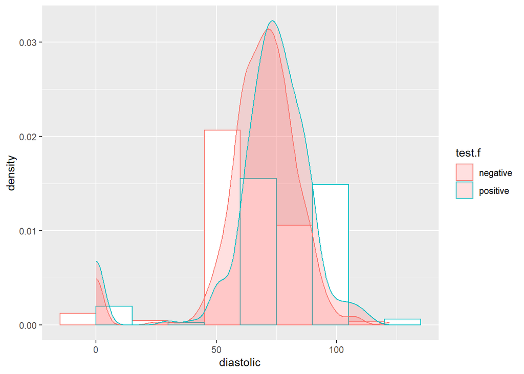

```r
ggplot(pima, aes(x=diastolic, y=..density.., color=test.f)) +
  geom_histogram(position='dodge',binwidth = 30, fill="white") +
  geom_density(alpha=.2, fill="#FF6666")
```

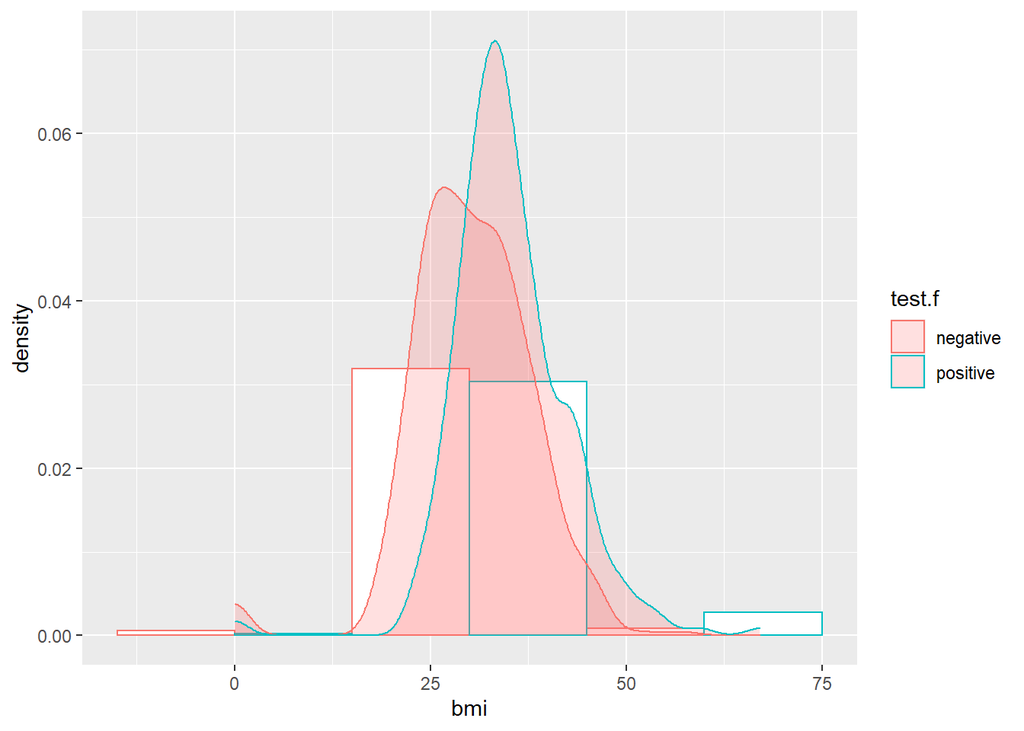

```r
ggplot(pima, aes(x=bmi, y=..density.., color=test.f)) +
  geom_histogram(position='dodge',binwidth = 30, fill="white") +
  geom_density(alpha=.2, fill="#FF6666")
```

Naime, kada pogledamo prethodne histograme, uocavaju se odredjene nepravilnosti medju podacima. Odredjen deo podataka za vrednost obelezja uzima vrednost 0. Vrednost 0 nije u skladu sa prirodom ovih obelezja. Na primer, nemoguce je imati kolicinu insulina ili glukoze u krvi 0, ili debljinu koze 0mm, ili imati telesni maseni indeks 0 (bmi= kg/m^2 -> nemoguce je biti tezak 0kg), ili krvni pritisak 0.

Ovakve vrednosti cemo smatrati pogresnim i uklonicemo ih iz baze. Uklanjanje cemo izvrsiti tako sto cemo napraviti nova obelezja sa sufiksom N, koja ce umesto 0 imati nedostajucu vrednost, a potom cemo iz baze ukloniti sve redove koji sadrze nedostajuce vrednosti. Ovim postupkom cemo postici vecu tacnost u predvidjanju naseg modela. (drugi moguci nacin je bio da se umesto 0 unesu srednje vrednosti za atribute na osnovu trening skupa)

```r
#PREPROCESIRANJE
pima$insulinN <- pima$insulin
pima$insulinN[pima$insulin==0] <- NA

pima$glucoseN <- pima$glucose
pima$glucoseN[pima$glucose==0] <- NA

pima$tricepsN <- pima$triceps
pima$tricepsN[pima$triceps==0] <- NA

pima$diastolicN <- pima$diastolic
pima$diastolicN[pima$diastolic==0] <- NA

pima$bmiN <- pima$bmi
pima$bmiN[pima$bmi==0] <- NA
table(pima$test)
```

```
##
##   0   1
## 500 268
```

```r
pima<-na.omit(pima)
summary(pima)
```

```
##     pregnant         glucose        diastolic         triceps
##  Min.   : 0.000   Min.   : 56.0   Min.   : 24.00   Min.   : 7.00
##  1st Qu.: 1.000   1st Qu.: 99.0   1st Qu.: 62.00   1st Qu.:21.00
##  Median : 2.000   Median :119.0   Median : 70.00   Median :29.00
##  Mean   : 3.301   Mean   :122.6   Mean   : 70.66   Mean   :29.15
##  3rd Qu.: 5.000   3rd Qu.:143.0   3rd Qu.: 78.00   3rd Qu.:37.00
##  Max.   :17.000   Max.   :198.0   Max.   :110.00   Max.   :63.00
##     insulin            bmi           diabetes           age
##  Min.   : 14.00   Min.   :18.20   Min.   :0.0850   Min.   :21.00
##  1st Qu.: 76.75   1st Qu.:28.40   1st Qu.:0.2697   1st Qu.:23.00
##  Median :125.50   Median :33.20   Median :0.4495   Median :27.00
##  Mean   :156.06   Mean   :33.09   Mean   :0.5230   Mean   :30.86
##  3rd Qu.:190.00   3rd Qu.:37.10   3rd Qu.:0.6870   3rd Qu.:36.00
##  Max.   :846.00   Max.   :67.10   Max.   :2.4200   Max.   :81.00
##       test             test.f       insulinN         glucoseN
##  Min.   :0.0000   negative:262   Min.   : 14.00   Min.   : 56.0
##  1st Qu.:0.0000   positive:130   1st Qu.: 76.75   1st Qu.: 99.0
##  Median :0.0000                  Median :125.50   Median :119.0
##  Mean   :0.3316                  Mean   :156.06   Mean   :122.6
##  3rd Qu.:1.0000                  3rd Qu.:190.00   3rd Qu.:143.0
##  Max.   :1.0000                  Max.   :846.00   Max.   :198.0
##     tricepsN       diastolicN          bmiN
##  Min.   : 7.00   Min.   : 24.00   Min.   :18.20
##  1st Qu.:21.00   1st Qu.: 62.00   1st Qu.:28.40
##  Median :29.00   Median : 70.00   Median :33.20
##  Mean   :29.15   Mean   : 70.66   Mean   :33.09
##  3rd Qu.:37.00   3rd Qu.: 78.00   3rd Qu.:37.10
##  Max.   :63.00   Max.   :110.00   Max.   :67.10
```

```r
table(pima$test)
```

```
##
##   0   1
## 262 130
```

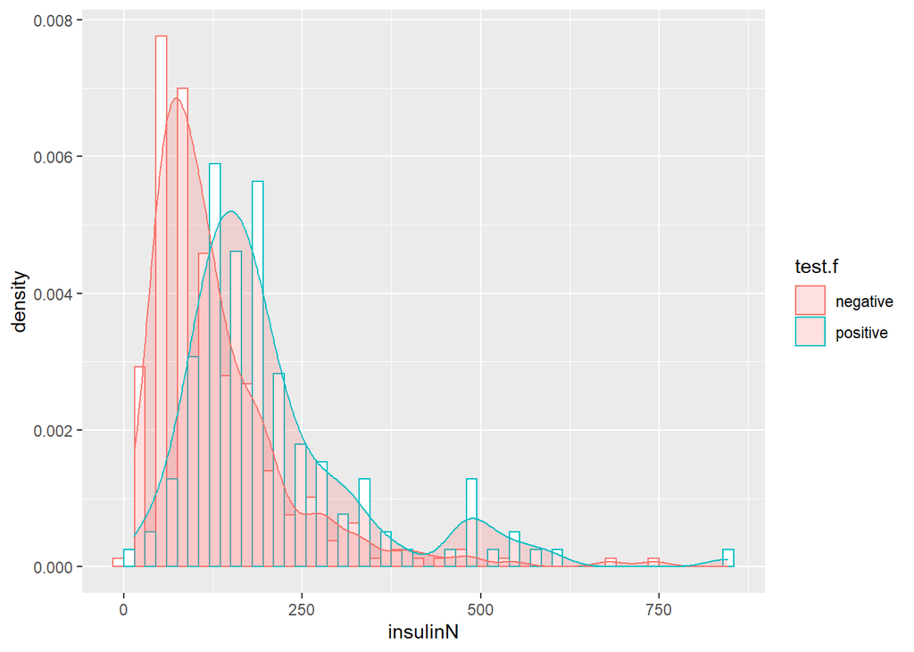

```r
ggplot(pima, aes(x=insulinN, y=..density.., color=test.f)) +
  geom_histogram(position='dodge',binwidth = 30, fill="white") +
  geom_density(alpha=.2, fill="#FF6666")
```

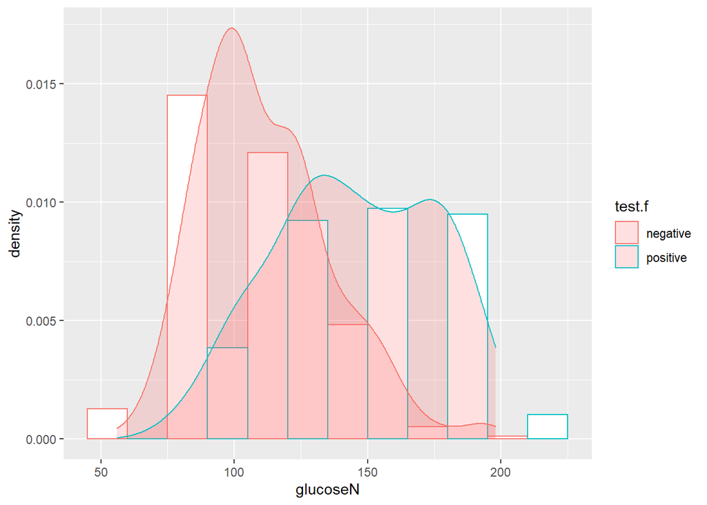

```r
ggplot(pima, aes(x=glucoseN, y=..density.., color=test.f)) +
  geom_histogram(position='dodge',binwidth = 30, fill="white") +
  geom_density(alpha=.2, fill="#FF6666")
```

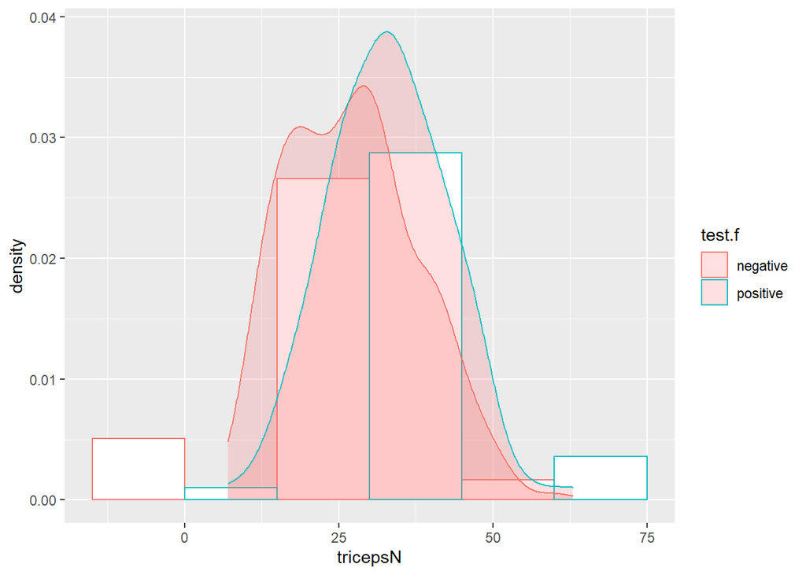

```r
ggplot(pima, aes(x=tricepsN, y=..density.., color=test.f)) +
  geom_histogram(position='dodge',binwidth = 30, fill="white") +
  geom_density(alpha=.2, fill="#FF6666")
```

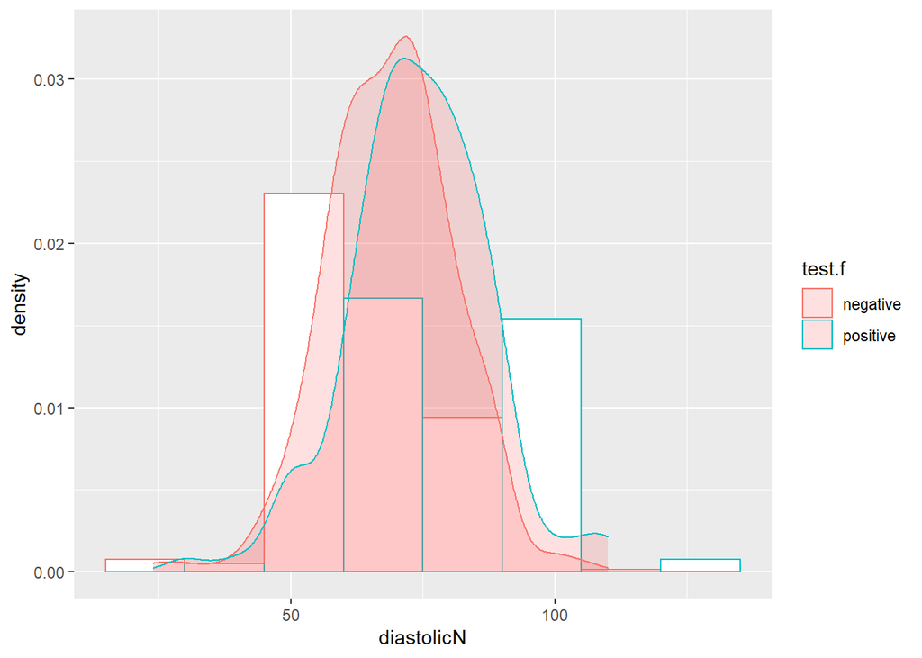

```r
ggplot(pima, aes(x=diastolicN, y=..density.., color=test.f)) +
  geom_histogram(position='dodge',binwidth = 30, fill="white") +
  geom_density(alpha=.2, fill="#FF6666")
```

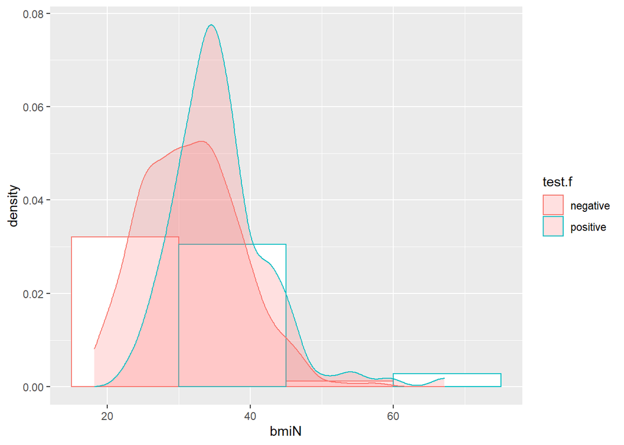

```r
ggplot(pima, aes(x=bmiN, y=..density.., color=test.f)) +
  geom_histogram(position='dodge',binwidth = 30, fill="white") +
  geom_density(alpha=.2, fill="#FF6666")
```

## Pravljenje modela

1. **Podela skupa na trening i test**

```r
set.seed(10)
podela <- caret::createDataPartition(y=pima$test,times=1,p=0.7,list=FALSE)
trening_skup<-pima[podela,]
test_skup<-pima[-podela,]
dim(trening_skup)
```

```
## [1] 275  15
```

```r
dim(test_skup)
```

```
## [1] 117  15
```

2. **Kreiranje modela**

```r
model<-glm(test~pregnant+glucoseN+diastolicN+tricepsN+bmiN+insulinN+diabetes+age,
           data=trening_skup)
summary(model)
```

```
##
## Call:
## glm(formula = test ~ pregnant + glucoseN + diastolicN + tricepsN +
##     bmiN + insulinN + diabetes + age, data = trening_skup)
##
## Deviance Residuals:
##      Min        1Q    Median        3Q       Max
## -1.21695  -0.25789  -0.07139   0.29062   0.94802
##
## Coefficients:
##               Estimate Std. Error t value Pr(>|t|)
## (Intercept) -9.391e-01  1.795e-01  -5.232 3.41e-07 ***
## pregnant     1.718e-02  1.021e-02   1.683  0.09351 .
## glucoseN     6.605e-03  9.798e-04   6.741 9.75e-11 ***
## diastolicN  -4.914e-04  2.173e-03  -0.226  0.82131
## tricepsN     2.537e-04  3.047e-03   0.083  0.93370
## bmiN         7.836e-03  4.915e-03   1.594  0.11202
## insulinN    -6.064e-05  2.651e-04  -0.229  0.81927
## diabetes     2.132e-01  7.245e-02   2.943  0.00354 **
## age          2.312e-03  3.463e-03   0.668  0.50488
## ---
## Signif. codes:  0 '***' 0.001 '**' 0.01 '*' 0.05 '.' 0.1 ' ' 1
##
## (Dispersion parameter for gaussian family taken to be 0.1565703)
##
##     Null deviance: 62.182  on 274  degrees of freedom
## Residual deviance: 41.648  on 266  degrees of freedom
## AIC: 281.35
##
## Number of Fisher Scoring iterations: 2
```

Kada smo kreirali model, iz tabele, na osnovu p-vrednosti, vidimo da trenutno dosta prediktora nije značajno (p-vrednost je veća od 0.05). Kako tricepsN ima najveću vrednost, prvo ćemo izostaviti njega iz modela, pa analizirati kakav model dobijemo nakon toga.

```r
model<-glm(test~pregnant+glucoseN+diastolicN+bmiN+insulinN+diabetes+age,
           data=trening_skup)
summary(model)
```

```
##
## Call:
## glm(formula = test ~ pregnant + glucoseN + diastolicN + bmiN +
##     insulinN + diabetes + age, data = trening_skup)
##
## Deviance Residuals:
##     Min       1Q   Median       3Q      Max
## -1.2157  -0.2583  -0.0683   0.2909   0.9459
##
## Coefficients:
##               Estimate Std. Error t value Pr(>|t|)
## (Intercept) -9.408e-01  1.779e-01  -5.288 2.58e-07 ***
## pregnant     1.718e-02  1.019e-02   1.686  0.09301 .
## glucoseN     6.602e-03  9.775e-04   6.754 8.96e-11 ***
## diastolicN  -4.874e-04  2.169e-03  -0.225  0.82237
## bmiN         8.085e-03  3.897e-03   2.075  0.03896 *
## insulinN    -6.047e-05  2.646e-04  -0.229  0.81943
## diabetes     2.134e-01  7.228e-02   2.953  0.00343 **
## age          2.343e-03  3.437e-03   0.682  0.49608
## ---
## Signif. codes:  0 '***' 0.001 '**' 0.01 '*' 0.05 '.' 0.1 ' ' 1
##
## (Dispersion parameter for gaussian family taken to be 0.155988)
##
##     Null deviance: 62.182  on 274  degrees of freedom
## Residual deviance: 41.649  on 267  degrees of freedom
## AIC: 279.35
##
## Number of Fisher Scoring iterations: 2
```

Sada, na osnovu ovakvog modela, vidimo da i dalje ima dosta neznačajnih prediktora, ali je bmiN postao značajan. Kako sada diastolicN ima najveću p-vrednost, uklanjamo njega iz modela, i formiramo novi model.

```r
model<-glm(test~pregnant+glucoseN+bmiN+insulinN+diabetes+age,
           data=trening_skup)
summary(model)
```

```
##
## Call:
## glm(formula = test ~ pregnant + glucoseN + bmiN + insulinN +
##     diabetes + age, data = trening_skup)
##
## Deviance Residuals:
##      Min        1Q    Median        3Q       Max
## -1.21608  -0.25810  -0.07362   0.28670   0.93830
##
## Coefficients:
##               Estimate Std. Error t value Pr(>|t|)
## (Intercept) -9.611e-01  1.530e-01  -6.281 1.35e-09 ***
## pregnant     1.709e-02  1.016e-02   1.681  0.09384 .
## glucoseN     6.577e-03  9.695e-04   6.784 7.46e-11 ***
## bmiN         7.873e-03  3.774e-03   2.086  0.03793 *
## insulinN    -5.598e-05  2.634e-04  -0.213  0.83185
## diabetes     2.137e-01  7.214e-02   2.962  0.00333 **
## age          2.199e-03  3.371e-03   0.652  0.51475
## ---
## Signif. codes:  0 '***' 0.001 '**' 0.01 '*' 0.05 '.' 0.1 ' ' 1
##
## (Dispersion parameter for gaussian family taken to be 0.1554353)
##
##     Null deviance: 62.182  on 274  degrees of freedom
## Residual deviance: 41.657  on 268  degrees of freedom
## AIC: 277.41
##
## Number of Fisher Scoring iterations: 2
```

Pošto još uvek postoje prediktori sa velikom p-vrednošću, izostavićemo insulinN iz modela.

```r
model<-glm(test~pregnant+glucoseN+bmiN+diabetes+age,
           data=trening_skup)
summary(model)
```

```
##
## Call:
## glm(formula = test ~ pregnant + glucoseN + bmiN + diabetes +
##     age, data = trening_skup)
##
## Deviance Residuals:
##      Min        1Q    Median        3Q       Max
## -1.23867  -0.25659  -0.07327   0.28810   0.94171
##
## Coefficients:
##               Estimate Std. Error t value Pr(>|t|)
## (Intercept) -0.9527946  0.1476384  -6.454 5.07e-10 ***
## pregnant     0.0171135  0.0101448   1.687  0.09278 .
## glucoseN     0.0064664  0.0008154   7.930 5.89e-14 ***
## bmiN         0.0078055  0.0037543   2.079  0.03856 *
## diabetes     0.2125586  0.0718140   2.960  0.00335 **
## age          0.0021813  0.0033639   0.648  0.51725
## ---
## Signif. codes:  0 '***' 0.001 '**' 0.01 '*' 0.05 '.' 0.1 ' ' 1
##
## (Dispersion parameter for gaussian family taken to be 0.1548836)
##
##     Null deviance: 62.182  on 274  degrees of freedom
## Residual deviance: 41.664  on 269  degrees of freedom
## AIC: 275.45
##
## Number of Fisher Scoring iterations: 2
```

Konačno, uklanjamo i prediktor age iz modela.

```r
model<-glm(test~pregnant+glucoseN+bmiN+diabetes,
           data=trening_skup)
summary(model)
```

```
##
## Call:
## glm(formula = test ~ pregnant + glucoseN + bmiN + diabetes, data = trening_skup)
##
## Deviance Residuals:
##      Min        1Q    Median        3Q       Max
## -1.25782  -0.25769  -0.07148   0.27947   0.94549
##
## Coefficients:
##               Estimate Std. Error t value Pr(>|t|)
## (Intercept) -0.9213792  0.1393135  -6.614 2.00e-10 ***
## pregnant     0.0215235  0.0075196   2.862  0.00453 **
## glucoseN     0.0065962  0.0007896   8.354 3.51e-15 ***
## bmiN         0.0079108  0.0037468   2.111  0.03566 *
## diabetes     0.2161144  0.0715275   3.021  0.00276 **
## ---
## Signif. codes:  0 '***' 0.001 '**' 0.01 '*' 0.05 '.' 0.1 ' ' 1
##
## (Dispersion parameter for gaussian family taken to be 0.1545512)
##
##     Null deviance: 62.182  on 274  degrees of freedom
## Residual deviance: 41.729  on 270  degrees of freedom
## AIC: 273.88
##
## Number of Fisher Scoring iterations: 2
```

Svi prediktori su postali značajni, pa je ovo i naš konačni model. Neznačajne prediktore nismo uklanjali odjednom, zato što postoji mogućnost da kada jedan uklonimo, neki koji je bio neznačajan postane značajan.

3. **Evaluacija modela**

   U ovom delu vršimo testiranje našeg modela na trening, i test skupu, na osnovu čega možemo da zaključimo koliko dobro naš model radi, kao i da li je došlo do preprilagođavanja ili potprilagođavanja podacima.

```r
trening_skup$test<- factor(trening_skup$test)
p1<-predict(model,newdata = trening_skup,type="response")
d1<-ifelse(p1>0.5,1,0)
mean(d1==trening_skup$test)
```

```
## [1] 0.7745455
```

```r
test_skup$test<- factor(test_skup$test)
p<-predict(model,newdata = test_skup,type="response")
#d-vrednosti klasifikovane modelom na test skupu
d<-ifelse(p>0.5,1,0)
mean(d==test_skup$test)
```

```
## [1] 0.8119658
```

```r
matrica_konfuzije=table(d,test_skup$test)

matrica_konfuzije
```

```
##
## d    0  1
##   0 76 16
##   1  6 19
```

```r
TN=matrica_konfuzije[1,1]
FP=matrica_konfuzije[1,2]
FN=matrica_konfuzije[2,1]
TP=matrica_konfuzije[2,2]

tacnost=(TP+TN)/(TP+TN+FP+FN)
senzitivnost=TP/(TP+FN)
specificnost=TN/(TN+FP)
preciznost=TP/(TP+FP)
fpr=FP/(TN+FP)
f1=2*preciznost*senzitivnost/(preciznost+senzitivnost)

cat("Tacnost: ",tacnost,"\n")
```

```
## Tacnost:  0.8119658
```

```r
cat("Senzitivnost: ",senzitivnost,"\n")
```

```
## Senzitivnost:  0.76
```

```r
cat("Specificnost: ",specificnost,"\n")
```

```
## Specificnost:  0.826087
```

```r
cat("Precizost: ",preciznost,"\n")
```

```
## Precizost:  0.5428571
```

```r
cat("fpr:",fpr,"\n")
```

```
## fpr: 0.173913
```

```r
cat("f1: ",f1,"\n")
```

```
## f1:  0.6333333
```

```r
library(pROC)
kriva<-roc(test_skup$test ~ d,data=test_skup)
```

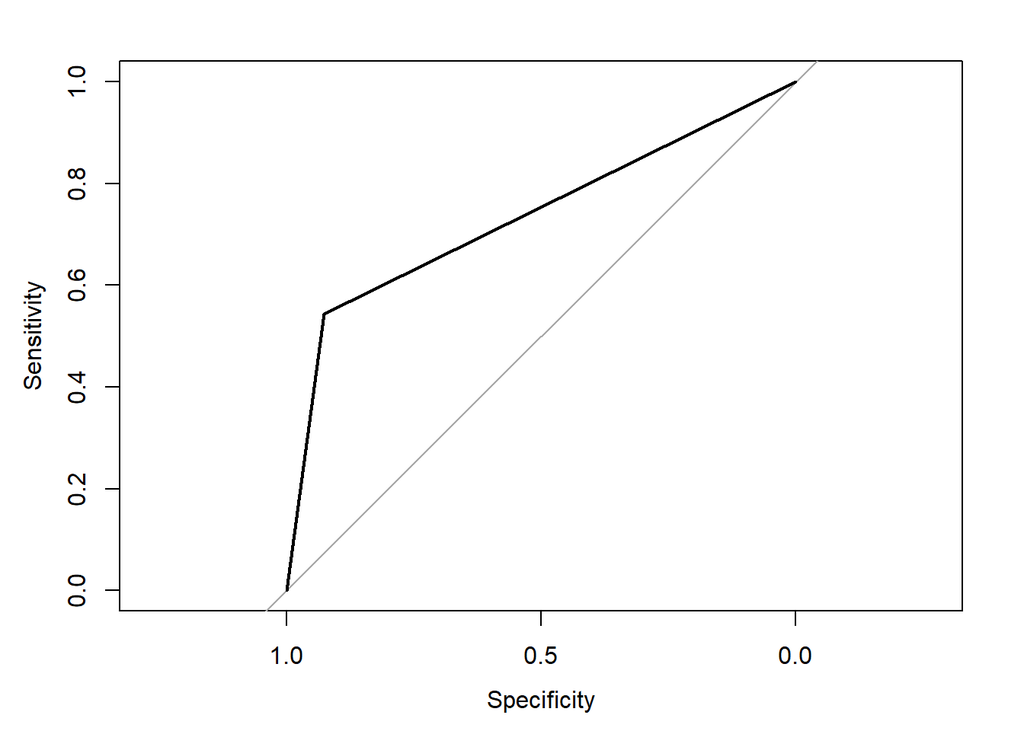

```r
plot(kriva)
```

```r
auc(kriva)
```

```
## Area under the curve: 0.7348
```

```r
#write.csv(trening_skup,file = "trening.csv")
#write.csv(test_skup,file="test.csv")
```

Vidimo da je tačnost našeg modela na trening skupu 77.5%, dok je na test skupu 81.2%. Na osnovu ovoga možemo da zaključimo da nije došlo do preprilagođavanja, jer model daje slične rezultate i na trening i na test skupu, a ni do potprilagođavanja. Model ne radi idealno, što je i očekivano, jer problem predviđanja dijabetesa nije lak, pa je ova tačnost prihvatljiva.

## Uporedjivanje sa drugim modelima (KNN i stabla odlucivanja u Python-u)

### Ucitavanje podataka

```python
import pandas as pd
trening=pd.read_csv("C:/Users/KORISNIK/Downloads/trening.csv")
test=pd.read_csv("C:/Users/KORISNIK/Downloads/test.csv")
feature_names=['pregnant','glucoseN','diastolicN','tricepsN','age','insulinN','bmiN']
x_train=trening[feature_names]
y_train=trening['test']

x_test=test[feature_names]
y_test=test['test']
```

### Standardizacija podataka

Posto cemo korisiti KNN, zasnovano na euklidskom rastojanju, podatke moramo standardizovati kako bi smo ih sveli na isti opseg vrednosti. Naime, ako je jedan atribut sireg opsega od ostalih, on sam moze uticati na klasifikaciju, gotovo zanemarujuci ostale atribute. Npr. atribut X uzima vrednosti [0,1], a Y [1,1000], u izracunavanju rastojanja vise utice atribut Y. Standardizacijom ovog problema nema.

```python
from sklearn.preprocessing import StandardScaler
scaler=StandardScaler()
scaler.fit(x_train)
```

```
## StandardScaler()
```

```python
x_train_std=pd.DataFrame(scaler.transform(x_train),columns=feature_names)
x_test_std=pd.DataFrame(scaler.transform(x_test),columns=feature_names)
```

StandardScaler nam omogucava da standardizujemo podatke, tako sto uceci na trening podacima racuna srednju vrednost i standardnu devijaciju svakog atributa pomocu kojih ih skalira. Podaci na test skupu se skaliraju pomocu vrednosti izracunatih iz trening skupa.

```python
from sklearn.model_selection import GridSearchCV
```

Prilikom pravljenja modela koristicemo unakrsnu validaciju, kojoj prosledjujemo koji model pravimo i sa mogucim vrednostima parametara tog modela. Unakrsnom validacijom mozemo dobiti model sa kombinacijom parametara takvom da daje najbolju tacnost.

## 1. Model-Stablo odlucivanja (DecisionTree)

```python
from sklearn.tree import DecisionTreeClassifier
params2={
    'criterion':['gini','entropy'],
    'max_depth':[3,4,5,6,7],
    'min_samples_leaf':[1,2,3,4,5,6,7]
}
model2=GridSearchCV(DecisionTreeClassifier(),param_grid=params2,cv=5,scoring='accuracy')
```

Stablo odlucivanja predstavlja model koji, kako mu ime kaze, prestablja stablo u cijem se korenu i unutrasnjim cvorovima nalaze odredjena ‘test pitanja’ na osnovu kojih se skup podataka deli, i u zavisnosti od odgovora prosledjuje deci tog svoga. Na primer ako su za pitanje moguci odgovori Da/Ne,slogovi koji odgovaraju sa Da idu u jedan dete-cvor, a sa Ne u drugi dete-cvor. Opisani postupak se izvrsava rekurzivno sve dok se u cvoru ne nalaze slogovi jedne iste klase, tada se klasifikacija zavsava a taj cvor, odnosno list, klasifikujemo odgovarajucom klasom. Odabir test pitanja se vrsi uz pomoc mere necistoce koja procenjuje koliko je podela skupa dobra, ako podelimo skup tako da su u jednom cvoru slogovi samo jedne klase a u drugom druge klase, tada je mera necistoce 0, dok u najgorem slucaju ako su raspodeljeni u svakom cvoru po 50% jedne i 50% druge klase, tada je mera necistoce 1.

Za parametre naseg modela odabrali smo krijerijum necistoce, koji se moze racunati preko Ginijevog indeksa ili entropije. Drugi parametar je maksimalna dubina stabla, a treci atribut je minimalan broj instanci u listovima.

```python
model2.fit(x_train,y_train)
```

```
## GridSearchCV(cv=5, estimator=DecisionTreeClassifier(),
##              param_grid={'criterion': ['gini', 'entropy'],
##                          'max_depth': [3, 4, 5, 6, 7],
##                          'min_samples_leaf': [1, 2, 3, 4, 5, 6, 7]},
##              scoring='accuracy')
```

```python
model2.best_estimator_
```

```
## DecisionTreeClassifier(max_depth=4, min_samples_leaf=6)
```

Obucavamo nas model na trening skupu(ne mora da bude standardizovan). Pomocu funkcije best_estimator_ dobijamo informaciju da model sa najvecom tacnoscu ima parametre: kriterijum=Gini (ne pise Gini posto je on podrazumevan), maksimalna dubina stabla = 4, minimalno cvorova u listu =6.

```python
y_train_pred2=model2.predict(x_train)
y_test_pred2=model2.predict(x_test)
```

Izracunavamo predvidjene vrednosti ciljne promenljive na trening i na test skupu kako bi smo ocenili koliko je dobar nas model.

```python
from sklearn.metrics import accuracy_score,confusion_matrix
```

Ucitavamo biblioteke koje nam omogucavaju da izracunamo matricu konfucije i tacnost

Tacnost:

-na trening skupu

```python
accuracy_score(y_train,y_train_pred2)
```

```
## 0.8048327137546468
```

```python
confusion_matrix(y_train,y_train_pred2)
```

```
## array([[303,  44],
##        [ 61, 130]], dtype=int64)
```

-na test skupu

```python
accuracy_score(y_test,y_test_pred2)
```

```
## 0.8376068376068376
```

```python
confusion_matrix(y_test,y_test_pred2)
```

```
## array([[72, 10],
##        [ 9, 26]], dtype=int64)
```

Na osnovu tacnosti vidimo da je ovaj model bolji od modela logisticke regresije, i da ni kod njega ne dolazi do preprilagodjavanja.

## 2.Model KNN

Kod modela KNN-K najblizih suseda, instancu klasifikujemo tako sto posmatramo njenih k najblizih suseda, koji se dobijaju racunanjem euklidskog rastojanja(zato smo morali da standardizujemo podatke).

```python
from sklearn.neighbors import KNeighborsClassifier
params={
    'n_neighbors':[3,4,5,6,7,8],
    'weights':['uniform','distance']
}
model1=GridSearchCV(KNeighborsClassifier(),param_grid=params,cv=5,scoring='accuracy')
```

Za parametre modela uzimamo koliko najblizih suseda posmatramo za datu instancu, i ‘weights’ koji oznacava da li svi susedi imaju jednak udeo u racunanju kojoj klasi pripada tada instanca. Ukoliko je podesen na ‘uniform’, odredjivanje klase se svodi na prebrojavanje kojim klasama pripadaju njegovi susedi, i klasifikuje se onom klasom kojoj pripada vise suseda. Kod ‘distance’ ne uzimaju svi susedi jednak udeo u racunanju klase, svakom susedu se dodeljuje tezina koja je obrnuto proporcijalna rastojanju od instance koju klasifikujemo. Ovime blizi susedi imaju veci udeo u racunanju klase za razliku od dosta udaljenijih.

Sada ucimo model na standardizovanim trening podacima.

```python
model1.fit(x_train_std,y_train)
```

```
## GridSearchCV(cv=5, estimator=KNeighborsClassifier(),
##              param_grid={'n_neighbors': [3, 4, 5, 6, 7, 8],
##                          'weights': ['uniform', 'distance']},
##              scoring='accuracy')
```

```python
model1.best_params_
```

```
## {'n_neighbors': 5, 'weights': 'distance'}
```

Na osnovu dobijenog modela dobijamo da su najbolji parametri: broj suseda=5 i ‘weights’-‘distance’

Racunanje predvidjenih vrednost:

```python
y_train_pred=model1.predict(x_train_std)
y_test_pred=model1.predict(x_test_std)
```

Tacnost:

-na trening skupu:

```python
accuracy_score(y_train,y_train_pred)
```

```
## 1.0
```

```python
confusion_matrix(y_train,y_train_pred)
```

```
## array([[347,   0],
##        [  0, 191]], dtype=int64)
```

-na test skupu:

```python
accuracy_score(y_test,y_test_pred)
```

```
## 0.9316239316239316
```

```python
confusion_matrix(y_test,y_test_pred)
```

```
## array([[76,  6],
##        [ 2, 33]], dtype=int64)
```

Ovaj model ima najbolju tacnost i na trening i na test skupu, ali posto je tacnost 1.00 na trening skupu a 0.93 na test skupu vidimo da je doslo do preprilagodjavanja trening skupu.